# Homework 1

資管二 李訓佑 b11705022

# Problem 1 myknn_regressor

## Q1.1 Create your myknn_regressor based on the skeleton.

### Get the K-means for `x_test` through predict

1. Calculate all norm for each `x_test[i]`, store it into `distance = [[y_train[i], distance to x_train[i]], ...]` (only k values inside)
2. For "remove_outliers" cases, we need to determine the distance for each val in `distance`, if distance[i][0] is not in [Q1-1.5IQR, Q3+1.5IQR], delete it.

```python
import numpy as np
import math
import matplotlib.pyplot as plt


class myknn_regressor():
    def __init__(self, n_neighbors=10, mean_type="equal_weight"):
        """mean_type can be equal_weight or remove_outliers.
                              equal_weight use the same weight for all neighbors.
                              remove_outliers remove neighbors out in [Q1 - 1.5 IQR, Q3 + 1.5IQR]."""
        self.k = n_neighbors
        self.mean_type = mean_type

    def fit(self, x_train, y_train):

        self.x_train = np.array(x_train)
        self.y_train = np.array(y_train)

    def predict(self, x_test):
        prediction = []
        for x in x_test:
            distance = []
            neighbors = []

            # cal norm
            for i in range(len(self.x_train)):
                distance.append(
                    [self.y_train[i], np.linalg.norm(x-self.x_train[i])])
            distance.sort(key=lambda x: x[1])

            # get top k
            neighbors = [distance[j][0] for j in range(self.k)]

            # if remove outliers, k >= 10
            if (self.mean_type == "remove_outliers") and (self.k >= 10):
                Q = np.percentile(neighbors, [25, 75])
                Q1 = Q[0]
                Q3 = Q[1]
                iqr = Q3-Q1
                neighbors = [distance[j][0] for j in range(self.k) if (
                    (distance[j][0] >= (Q1-1.5*iqr)) and (distance[j][0] <= (Q3+1.5*iqr)))]

            prediction.append(np.mean(neighbors))

        return np.array(prediction)
```

The result for Q1.1 can be seen at Q1.2, which works like a charm!

## Q1.2 Load data from msd_data1.pickle, Make predictions using k=20 and "equal_weight" f List the RMSE and the first 20 predictions in the test data.

1. Read the data through the code given from the example, which normalize the data for us through `xscaler.transform(msd_data['X_train'])`
2. Set `myknn1` & `myknn2` objects, and throw our training data inside
3. Calculate the RMSE = `np.linalg.norm(ypred - Y_test)/np.sqrt(len(ypred))`

```python
import pickle
from sklearn import preprocessing
import numpy as np

# Load data
with open('msd_data1.pickle', 'rb') as fh1:
    msd_data = pickle.load(fh1)

doscaling = 1

if (doscaling == 1):
    xscaler = preprocessing.StandardScaler().fit(msd_data['X_train'])
    # standardize feature values
    X_train = xscaler.transform(msd_data['X_train'])
    X_test = xscaler.transform(msd_data['X_test'])
else:
    X_train = msd_data['X_train']
    X_test = msd_data['X_test']

Y_train = msd_data['Y_train']
Y_test = msd_data['Y_test']
```

```python
myknn1 = myknn_regressor(20, "equal_weight")
myknn1.fit(X_train, Y_train)
ypred = myknn1.predict(X_test)
RMSE = np.linalg.norm(ypred - Y_test)/np.sqrt(len(ypred))
print(ypred[:20])
print("RMSE:", RMSE)
```

```
[1993.35 1993.8  2000.65 1991.5  1992.8  1998.5  1988.1  1991.65 2002.25
 2003.   2000.5  1998.65 1995.55 1997.2  1995.05 1997.4  1992.15 2000.45
 2003.2  1995.75]
RMSE: 10.251264515495961
```

The result is exactly like `sklearn.neighbors.KNeighborsRegressor` for `equal_weight`, which is tested by my self privately.

## Q1.3 Load data from msd_data1.pickle, Make predictions using k=20 and "remove_outliers" f List the RMSE and the first 20 predictions in the test data.

Process same as above, simply change "equal_weight" to "remove_outliers"

```python
myknn1 = myknn_regressor(20, "remove_outliers")
myknn1.fit(X_train, Y_train)
ypred = myknn1.predict(X_test)
RMSE = np.linalg.norm(ypred - Y_test)/np.sqrt(len(ypred))
print(ypred[:20])
print("RMSE:", RMSE)
```

```
[1993.35       1993.8        2000.65       1992.73684211 1992.8
 2000.         1988.1        1991.65       2002.25       2003.94736842
 2000.5        2000.94444444 1995.55       1997.2        1998.61111111
 1997.4        1992.15       2003.83333333 2003.2        1995.75      ]
RMSE: 10.212572466080381
```

For `remove_outliers` I think it turned out pretty good, where the RMSE is lower.

# Problem 2 Tuning the Hyper-parameter

In order to do so, we need to create a list of `k_list` to test each k value.

Case1 : We import `from sklearn.neighbors import KNeighborsRegressor` to train the model with different k val.

Case2 : We use that package again, however we use `msd_data['X_train'], msd_data['Y_train']` instead

Case3 : We use the Class create by my self with "remove_outliers", and iterate through `k_list`

Last of all, stuff all of the trained value (which is result1, 2, 3) inside the plot through `plt.scatter` and `plt.plot`

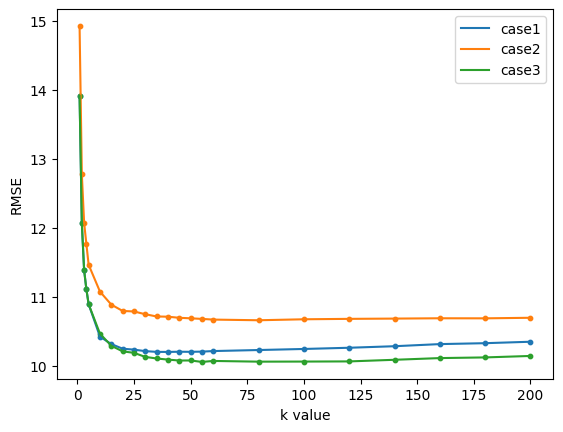

```python
from sklearn.neighbors import KNeighborsRegressor

k_list = [1, 2, 3, 4, 5, 10, 15, 20, 25, 30, 35, 40,
          45, 50, 55, 60, 80, 100, 120, 140, 160, 180, 200]
result1 = []

for k in k_list:
    KNN1 = KNeighborsRegressor(k)
    KNN1.fit(X_train, Y_train)
    sklearn_ypred = KNN1.predict(X_test)
    RMSE = math.sqrt(sum((sklearn_ypred - Y_test)**2)/len(sklearn_ypred))
    result1.append(RMSE)

result2 = []
for k in k_list:
    KNN2 = KNeighborsRegressor(k)
    KNN2.fit(msd_data['X_train'], msd_data['Y_train'])
    sklearn_ypred = KNN2.predict(msd_data['X_test'])
    RMSE = math.sqrt(
        sum((sklearn_ypred - msd_data['Y_test'])**2)/len(sklearn_ypred))
    result2.append(RMSE)

# this took 10 minutes
result3 = []
for k in k_list:
    KNN3 = myknn_regressor(k, "remove_outliers")
    KNN3.fit(X_train, Y_train)
    sklearn_ypred = KNN3.predict(X_test)
    RMSE = math.sqrt(sum((sklearn_ypred - Y_test)**2)/len(sklearn_ypred))
    result3.append(RMSE)


plt.scatter(k_list, result1, s=10)
plt.scatter(k_list, result2, s=10)
plt.scatter(k_list, result3, s=10)


plt.plot(k_list, result1, linestyle='-', marker='', label='case1')
plt.plot(k_list, result2, linestyle='-', marker='', label='case2')
plt.plot(k_list, result3, linestyle='-', marker='', label='case3')


plt.xlabel("k value")
plt.ylabel("RMSE")
plt.legend()
```

From the plot, we can see that Case3 performs the best, which deletes outlier values.

The second best is Case1, which does normalization before training, however doesn't delete outlier val.

Case2 performs the worst, which takes raw input only.

As a conclusion, with normalization for training data can improve the model's performance well. Moreover, deleting outlier values also improve the model as well.

With K value big enough, but not too big, we can see that the model reach its best performance, which is around 25-50.

# Problem 3 Lasso Regression

## Q3.1 基於本題給的 L 推導新的 Coordinate Descent with Soft Thresholding 公式。

The first line is the given definition of loss function. I changed `i` to `n` , `j` to `k` , `n` to `N`, in order to cope with the parameter given in lecture PPT.

The second line is to differetiate the loss function w.r.t. Moreover, I changed Xn into $ \phi (Xn) $ also to cope with the symbol used in lecture PPT.

The third line uses another notation which is $ \phi _{n,-j}$ also from lecture PPT.

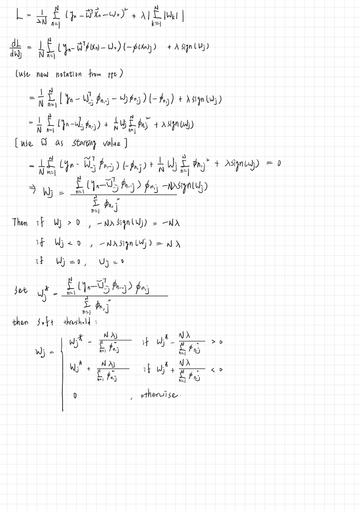

```python
from IPython.display import Image

# Specify the path to your image file
image_path = "prove.jpg"  # Replace with the path to your image file

# Display the image in the Jupyter Notebook
Image(filename=image_path)
```

Basically, the only difference to the PPT is that there is `N` before $\lambda$, at soft threshold

## Q3.2 使用給定個骨架建構你的 mylasso

1. Build function `ridge_regression()` to get the first $W = (X^TX + \lambda I)^{-1}X^Ty$
2. Start iterating, until `max_iter`, and run `self.Lasso_regression()`
3. For `self.Lasso_regression()` it iterates every element in W, and do lasso regression.

   Steps for `Lasso_regerssion()`

   a. Find $Wj^{*}$ from the formula on the previous page, which is $(Y - W_{-j}^{T} X_{-j})X_j / (X_{j}^{T} X_{j})$ = `np.matmul(xj.T , self.y_train-ypred+self.W[j]*xj) / xjsquare`

   c. Throw the rest of w1~wn to `soft_threshold()` -> also the formula from above.

   d. new W is updated
4. Calculate the Training Loss, which is $L = \frac{1}{2N} \Sigma_{n=1}^N (y_{n} - W^{T} X_{n} - W_{0})^{2} + \lambda sign(W_{j})$ = `np.sum(np.square(self.y_train - np.matmul(self.x_train, self.W)))/(2*self.m) + self.lamcoef*(np.sum(abs(self.W)) - self.W[0])`
5. Since the last one won't be the best one, store L and W into L_list, W_list
6. Check verbose, if true output the needed values
7. Check the difference between L and the previous L', if smaller than `self.tol` stop the loop and return `smallest_Loss, RMSE_final, MAE_final, W_final[0], W_final[1:].flatten(), non_zero`
8. Before returning, check `keep_trainingdata`, if false del x_train and y_train

```python
import numpy as np
import copy


class mylasso():
    def __init__(self, lamcoef=0.1, max_iter=1000, tol=1e-6, const_regu=False):
        """lamcoef: the regularization coefficient
           max_iter: maximum number of iteration for model training
           tol: tolerance for the stopping criteria for model training
           const_regu: whether the constant term should be regularized, default to False
           """
        ### Add your code here ###
        self.lamcoef = lamcoef
        self.max_iter = max_iter
        self.tol = tol
        self.const_regu = const_regu

    def fit(self, x_train, y_train, winit="ridge", keep_traindata=True, verbose=False):
        """Fit a Lasso model
           x_train: a numpy matrix that contains training features
           y_train: a numpy matrix that contains the label
           winit: how weights are initialized, default to "ridge", ridge regression
           keep_traindata: whether the object is going to keep training data after the training process completed
           verbose: output a lot of message"""

        ### Add your code here ###
        self.x_train = x_train
        self.y_train = y_train
        self.winit = winit
        self.keep_traindata = keep_traindata
        self.verbose = verbose

        # m datas, n dimention
        self.m, self.n = x_train.shape

        # get w init, if not ridge, set it to 1,1,1,1...
        if winit == "ridge":
            # n+1*1, m*n+1
            self.W, self.x_train = self.Ridge_regression()
            # m*1
            self.y_train = self.y_train.reshape(-1, 1)
        else:
            # n+1*1
            self.W = np.ones(self.n+1, 1)
            x1 = np.ones(self.m, 1)
            # m*n+1
            self.x_train = np.c_[x1, self.x_train]
            # m*1
            self.y_train = self.y_train.reshape(-1, 1)

        L_list = []
        W_list = []
        for run_cnt in range(self.max_iter):
            # calculate diff after update
            w_prev = self.W.copy()

            # do lasso regression
            self.Lasso_regression()

            # calculate L
            L = np.sum(np.square(self.y_train - np.matmul(self.x_train, self.W))) / \
                (2*self.m) + self.lamcoef*(np.sum(abs(self.W)) - self.W[0])
            L_prev = np.sum(np.square(self.y_train - np.matmul(self.x_train, w_prev))) / \
                (2*self.m) + self.lamcoef*(np.sum(abs(w_prev)) - w_prev[0])
            diff = abs(L-L_prev)

            # add into history
            L_list.append(L)
            W_list.append(self.W)

            # print important things if verbose true
            if verbose:
                np.set_printoptions(suppress=True)
                print("Training Loss:", L)
                print("Root Mean Squared Error:", np.sqrt(
                    np.mean(np.square(np.matmul(self.x_train, self.W) - self.y_train))))
                print("Mean Absolute Value:", np.mean(
                    np.abs(np.matmul(self.x_train, self.W) - self.y_train)))
                print("Interception:", self.W[0])
                print("Feature Weights:", self.W[1:])
                print("Count of non-zero weights:",
                      np.count_nonzero(self.W[1:].flatten()))

            # check whether smaller than self.tol
            if diff < self.tol:
                np.set_printoptions(suppress=True)
                smallest_Loss = min(L_list)
                W_final = W_list[L_list.index(smallest_Loss)]
                RMSE_final = np.sqrt(
                    np.mean(np.square(np.matmul(self.x_train, W_final) - self.y_train)))
                MAE_final = np.mean(
                    abs(np.matmul(self.x_train, W_final) - self.y_train))
                non_zero = np.count_nonzero(W_final[1:].flatten())
                break

        # whether the object is going to keep training data after the training process completed
        if not keep_traindata:
            del self.x_train
            del self.y_train

        return smallest_Loss, RMSE_final, MAE_final, W_final[0], W_final[1:].flatten(), non_zero

    def predict(self, x):
        """Make prediction using trained model"""
        x = np.array(x)
        if x.shape[1] == self.n:
            tmp = np.ones((x.shape[0], 1))
            x = np.c_[tmp, x]
        return np.matmul(x, self.W)

    # W = (X^T*X + lamba*I)^-1X^Ty
    # return size w0 = 1*n, xtmp = m * (n+1)

    def Ridge_regression(self):
        # add a column of 1s in front of x_train
        x1 = np.ones((self.m, 1))
        xtmp = np.c_[x1, self.x_train]
        I = np.identity(self.n+1)
        # don't regulate w0
        I[0][0] = 0
        # use same lambda
        w0 = np.dot(np.dot(np.linalg.inv(np.dot(xtmp.T, xtmp) +
                    self.lamcoef*I), xtmp.T), self.y_train)
        return w0.reshape(-1, 1), xtmp

    # do coordinate descent
    def Lasso_regression(self):
        for j in range(self.n+1):
            xj = self.x_train[:, j].reshape(-1, 1)
            ypred = self.predict(self.x_train)

            # wjstar = (y - w * x (without wj, xij)) * xj / (xj^T * xj)
            xjsquare = np.matmul(xj.T, xj)
            wjstar = np.matmul(xj.T, self.y_train-ypred +
                               self.W[j]*xj) / xjsquare

            # regularize w0, L'
            if self.const_regu:
                if j == 0:
                    self.W[j] = wjstar
                else:
                    self.W[j] = self.soft_threshold(wjstar, xjsquare)
            # not regularize w0, L
            else:
                self.W[j] = self.soft_threshold(wjstar, xjsquare)

    # soft threshold
    def soft_threshold(self, wjstar, xjsquare):
        if ((wjstar - self.lamcoef*(self.m)/xjsquare) > 0):
            return wjstar - self.lamcoef*(self.m)/xjsquare
        elif ((wjstar + self.lamcoef*(self.m)/xjsquare) < 0):
            return wjstar + self.lamcoef*(self.m)/xjsquare
        else:
            return 0
```

## Q3.3 載入資料集，參數使用預設值。列出 Training Loss、Root Mean Squared Error (RMSE) in Training Data、Mean Absolute Error (MAE) in Training Data、Intercept (截距項)、Feature Weights (除了截距項的所有權重)、非零權重的個數。

1. Load & Standardize data through the code given
2. Initialize the Class object, and since the problem said that every parameter can be its default val, so we don't need to feed anything inside.
3. Start fitting through `model.fit(X_train_sd, Y_train)`
4. print out every needed data

```python
# load the dataset, and create normalized and raw features.
import pickle
from sklearn import preprocessing
import numpy as np
np.set_printoptions(suppress=True)

# Load data
with open('msd_data1.pickle', 'rb') as fh1:
    msd_data = pickle.load(fh1)

xscaler = preprocessing.StandardScaler().fit(msd_data['X_train'])
# standardize feature values
X_train_sd = xscaler.transform(msd_data['X_train'])
X_test_sd = xscaler.transform(msd_data['X_test'])

# outcome values
Y_train = msd_data['Y_train']
Y_test = msd_data['Y_test']
```

```python
model = mylasso(lamcoef=0.1)
Loss, RMSE, MAE, W0, W, non_zero = model.fit(X_train_sd, Y_train)

print(f"""
Training Loss:{Loss}
Root Mean Squared Error:{RMSE}
Mean Absolute Value:{MAE}
Interception:{W0}
Feature Weights:
{W}
Count of non-zero weights:{non_zero}
""")
```

```
Training Loss:[49.89340411]
Root Mean Squared Error:9.7200135052744
Mean Absolute Value:7.003889367216028
Interception:[1998.166]
Feature Weights:
[ 4.6518551  -2.45673153 -1.06195885  0.         -0.34275054 -2.94854329
  0.         -0.39970268 -0.42653866  0.         -0.23498651 -0.39491058
  0.50307719  0.         -0.34207893  0.61674589  0.15722753  0.43489925
  0.43595375  1.12941661  0.40663481  0.          1.77743607  0.
 -0.16842728  0.07833529  0.66391172  0.01297938  0.15350723  0.
 -0.21762074 -0.22189107  0.         -0.0027548  -0.01707674 -0.2599464
  0.          0.28969362  0.34893387  0.         -0.26112569 -0.14488702
 -0.00995271  0.03497723 -0.03984338  0.          0.00299383 -0.17804306
  0.          0.06494382  0.27076506  0.          0.          0.
  0.          0.         -0.63813223  0.23761428 -0.19016387  0.
 -0.18875525  0.         -0.13590668  0.0612754  -0.26619017  0.
  0.          0.         -0.03099184  0.         -0.19276517  0.01221358
  0.20735199  0.25118247  0.12313494  0.          0.         -0.52945662
  0.          0.          0.17859187  0.02408561  0.25291058  0.19360205
  0.37064854  0.          0.         -0.29169753  0.          0.        ]
Count of non-zero weights:59
```

The function worked out pretty good, output everything needed.

## Q3.4 使用上一小題的模型計算測試資料的預測值。列出前五筆資料的預測年分、Test RMSE、Test MAE

```python
y_pred = model.predict(X_test_sd)
np.set_printoptions(suppress=True)
print("Prediction:", y_pred[:5].flatten())
print("Right Y:", Y_test[:5])
print("Test RMSE:", np.sqrt(np.mean(np.square(y_pred.flatten() - Y_test))))
print("Test MAE", np.mean(np.abs(y_pred.flatten()-Y_test)))
```

```
Prediction: [1991.83191145 1998.97198637 2001.66293602 1991.20317029 1994.32657933]
Right Y: [1998. 1988. 2005. 1982. 1990.]
Test RMSE: 9.65007629917791
Test MAE 6.943728810915563
```

## Q3.5 記錄每一個 λ 的 Training Loss、Number of Nonzero Weights、Average Weight Size (Mean of Absolute Weight)、Training RMSE、Test RMSE。將所有的結果列表、畫折線圖、並寫下你對結果的觀察。

使用下面的 λ 訓練模型: 0.0001, 0.0005, 0.001, 0.005, 0.01, 0.05, 0.1, 0.5, 1, 2。

1. Create a list of needed lamdas, and iterate through it, get needed data from it.
2. which are `Training Loss` , `Number of Nonzero Weights` , `Average Weight Size (Mean of Absolute Weight)` , `Training RMSE` , `Test RMSE`

```python
import pandas as pd
import matplotlib.pyplot as plt
lambda_list = [0.0001, 0.0005, 0.001, 0.005, 0.01, 0.05, 0.1, 0.5, 1, 2]

history = []
for lambdas in lambda_list:
    model = mylasso(lamcoef=lambdas)
    Loss, RMSE, MAE, W0, W, non_zero = model.fit(X_train_sd, Y_train)
    y_pred = model.predict(X_test_sd)
    y_pred_RMSE = np.sqrt(np.mean(np.square(y_pred.flatten() - Y_test)))
    history.append([Loss[0], non_zero, np.mean(abs(W)), RMSE, y_pred_RMSE])

history_array = np.array(history)
```

### Plot it with pandas

```python
df = pd.DataFrame(history, columns=['Training Loss', 'Number of Nonzero Weights',
                  'Average Weight Size (Mean of Absolute Weight)', 'Training RMSE', 'Test RMSE'], index=lambda_list)
display(df)
```

|  | Training Loss | Number of Nonzero Weights | Average Weight Size (Mean of Absolute Weight) | Training RMSE | Test RMSE |
| --- | --- | --- | --- | --- | --- |
| 0.0001 | 46.570461 | 90 | 0.470656 | 9.650516 | 9.644375 |
| 0.0005 | 46.587379 | 90 | 0.469507 | 9.650518 | 9.644096 |
| 0.0010 | 46.608461 | 90 | 0.467906 | 9.650528 | 9.643547 |
| 0.0050 | 46.774669 | 89 | 0.455754 | 9.650863 | 9.640108 |
| 0.0100 | 46.976876 | 87 | 0.442903 | 9.651763 | 9.636501 |
| 0.0500 | 48.418640 | 76 | 0.363977 | 9.672719 | 9.627055 |
| 0.1000 | 49.893404 | 59 | 0.294897 | 9.720014 | 9.650076 |
| 0.5000 | 56.500688 | 16 | 0.120031 | 10.109331 | 10.021195 |
| 1.0000 | 60.389324 | 4 | 0.042175 | 10.638945 | 10.548061 |
| 2.0000 | 63.492131 | 1 | 0.004266 | 11.200386 | 11.141073 |

### Draw the diagram with matplotlib

##### Lamda to Training Loss

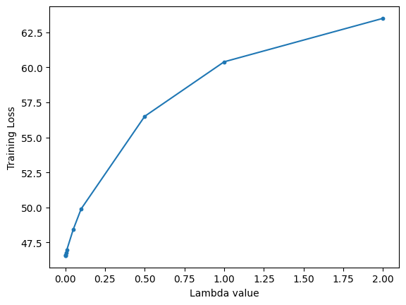

```python
plt.scatter(lambda_list, history_array[:, 0], s=10)
plt.plot(lambda_list, history_array[:, 0], linestyle='-', marker='')
plt.xlabel("Lambda value")
plt.ylabel("Training Loss")
# plt.legend()
```

#### Lambda to Number of nonzero weights

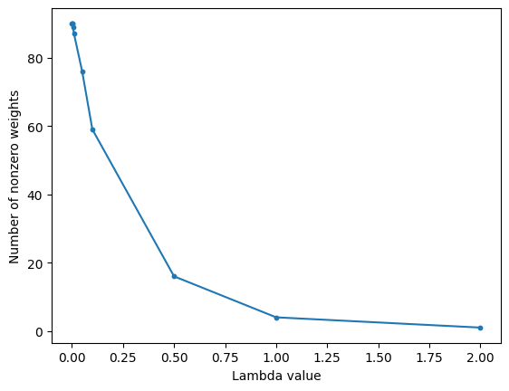

```python
plt.scatter(lambda_list, history_array[:, 1], s=10)
plt.plot(lambda_list, history_array[:, 1], linestyle='-', marker='')
plt.xlabel("Lambda value")
plt.ylabel("Number of nonzero weights")
```

#### Lambda to Mean of Abs weight

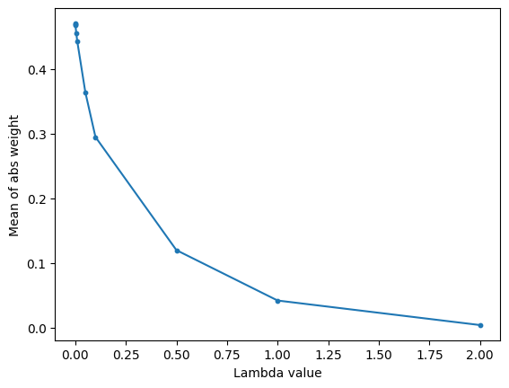

```python
plt.scatter(lambda_list, history_array[:, 2], s=10)
plt.plot(lambda_list, history_array[:, 2], linestyle='-', marker='')
plt.xlabel("Lambda value")
plt.ylabel("Mean of abs weight")
```

#### Lambda to Training RMSE

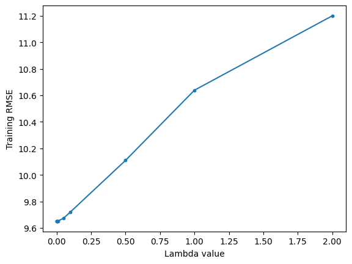

```python
plt.scatter(lambda_list, history_array[:, 3], s=10)
plt.plot(lambda_list, history_array[:, 3], linestyle='-', marker='')
plt.xlabel("Lambda value")
plt.ylabel("Training RMSE")
```

#### Lambda to Test RMSE

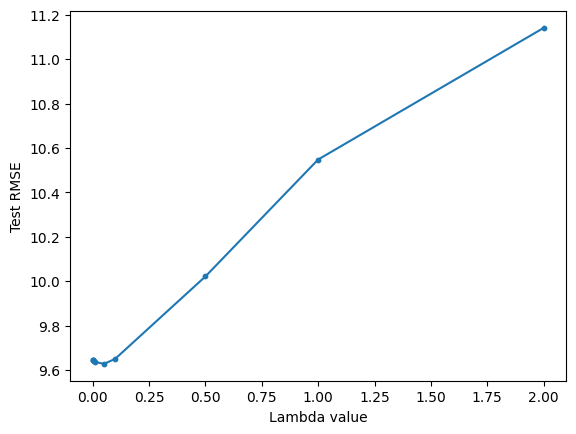

```python
plt.scatter(lambda_list, history_array[:, 4], s=10)
plt.plot(lambda_list, history_array[:, 4], linestyle='-', marker='')
plt.xlabel("Lambda value")
plt.ylabel("Test RMSE")
```

## Conclusion

1. For lambda to training loss, the lower the lambda, the training loss will be lower as well.
2. For lamda to number of nonzero weights, there is only 1 nonzero weight for lambda = 2, I think this is pretty astonishing, meaning that setting lambda = 2 is already too big, for lambda < 0.001, all weight will have a number.
3. For lambda to Mean of abs weight, it's a bit like the previous one, the lower the lambda, the mean is higher.
4. For Lambda to Training RMSE, as lambda decreases, the training RMSE decreases, the speed of decreasing decreases as well. When lambda changed from 0.0005 to 0.0001, the training RMSE changed 0.000002 only.
5. For lambda to test RMSE, the case is a bit different. When lambda = 0.05 performs the best. I think it might be the model overfit when lambda is < 0.05. The performance gets worse when we decrease lambda after 0.05.